# Assignment 2 - Integer Linear Programming

## Problem 1

Consider the following ILP:

$$\begin{aligned}
&\max \quad 9 x_{1}+5 x_{2}+6 x_{3}+4 x_{4}\\
&\text { s.t. } \quad \\
&6 x_{1}+3 x_{2}+5 x_{3}+2 x_{4} \leq 10, \\
&x_{3}+x_{4} \leq 1,\\
&-x_{1}+x_{3} \leq 0,\\
&-x_{2}+x_{4} \leq 0\\
&x_{1}, x_{2}, x_{3}, x_{4} \in\{0,1\}
\end{aligned}$$

The following tree represents the solutions of all possible relaxations of the problem in which no sub-problem has been excluded (fathoming).

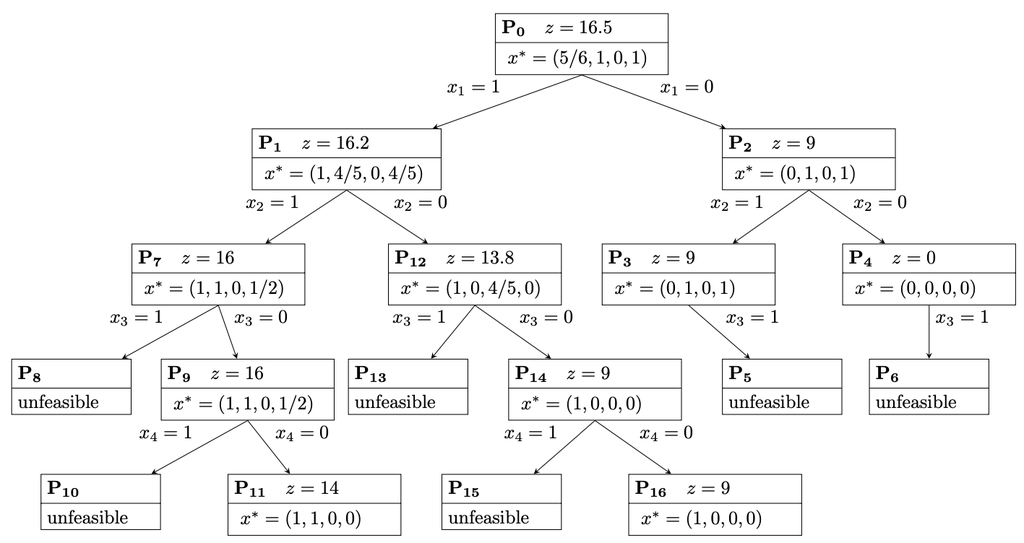

Suppose that the Branch and Bound (BB) algorithm applies to this problem. Also, let’s suppose that the algorithm visits the sub-problems in the following order P0 , P1 , . . . , P16. Clearly, the algorithm does not visit all nodes.

1) Determine the nodes that will be visited by the BB algorithm and for each of them get the upper and lower limit deduced by the algorithm in the execution.

Partendo da P<sub>0</sub> ed avendo variabili non intere l’algoritmo prosegue a P<sub>1</sub> dove raggiunge 16.2 come valore della funzione obiettivo; l’alternativa è P<sub>2</sub> dove però il valore della funzione obiettivo è 9 e quindi non viene preso in considerazione. Da P<sub>1</sub> dato che le variabili decisionali non sono tutte intere si passa a P<sub>7</sub> che ha un valore di 16 contro il valore di P<sub>12</sub> 13.8. Nel nodo P<sub>7</sub> le variabili non sono tutte intere quindi si procede al nodo P<sub>8</sub> che però non è ammissibile e quindi al nodo P<sub>9</sub> che rimane invariato rispetto al precedente, le variabili non sono ancora intere quindi l’algoritmo procede al nodo P<sub>10</sub> che non è ammissibile e quindi al nodo P<sub>11</sub> con un valore della funzione obiettivo di 14 e le variabili decisionali rispettivamente (1,1,0,0) L’upper bound di ogni nodo è il valore Z del problema “relaxed” mentre il lower bound consiste nella miglior soluzione fino a quel momento quindi ogni volta che trovo una soluzione, intera e feasible migliore, il limite inferiore viene aggiornato.

2. Solve the problem with an ILP solver and check the value of the objective function matches the one found at point 1.

```r
if(require(lpSolveAPI)==FALSE) install.packages("lpSolveAPI")
lp.model <- make.lp(0,4)
lp.control(lp.model, sense = "max")
```

[output not shown]

[output cut: 12 more lines]

[output not shown]

```r
set.objfn(lp.model, c(9,5,6,4))
add.constraint(lp.model, c(6,3,5,2), "<=", 10)
add.constraint(lp.model, c(0,0,1,1), "<=", 1)
add.constraint(lp.model, c(-1,0,1,0), "<=", 0)
add.constraint(lp.model, c(0,-1,0,1), "<=", 0)
set.bounds(lp.model, lower = rep(0,4), upper = rep(1,4))
set.type(lp.model, c(1:4), "binary")

lp.model
```

```
## Model name:
##            C1   C2   C3   C4
## Maximize    9    5    6    4
## R1          6    3    5    2  <=  10
## R2          0    0    1    1  <=   1
## R3         -1    0    1    0  <=   0
## R4          0   -1    0    1  <=   0
## Kind      Std  Std  Std  Std
## Type      Int  Int  Int  Int
## Upper       1    1    1    1
## Lower       0    0    0    0
```

```r
solve(lp.model)
```

```
## [1] 0
```

```r
get.objective(lp.model)
```

```
## [1] 14
```

```r
get.variables(lp.model)
```

```
## [1] 1 1 0 0
```

Sia il valore della funzione obiettivo che i valori delle variabili decisionali coincidono con quanto ricavato al punto precedente.

## Problem 2

SunNet is a residential Internet Service Provider (ISP) in the central Florida area. Presently, the company operates one centralized facility that all of its clients call into for Internet access.

To improve service, the company is planning to open three satellite offices in the cities of Pine Hills, Eustis, and Sanford. The company has identified five different regions to be serviced by these three offices. The following table summarizes the number of customers in each region, the service capacity at each office, and the monthly average cost per customer for providing the service to each region from each office. Table entries of “n.a.” indicate infeasible region-to-service center combinations.

SunNet would like to determine how many customers from each region to assign to each service center to minimize the total cost.

$$\begin{array}{lllll}
\text { Region } & \text { Pine Hills } & \text { Eustis } & \text { Sanford } & \text { Customers } \\
1 & \$ 6.50 & \$ 7.50 & \text { n.a. } & 30,000 \\
2 & \$ 7.00 & \$ 8.00 & \text { n.a. } & 40,000 \\
3 & \$ 8.25 & \$ 7.25 & \$ 6.75 & 25,000 \\
4 & \text { n.a. } & \$ 7.75 & \$ 7.00 & 35,000 \\
5 & \text { n.a. } & \$ 7.50 & \$ 6.75 & 33,000 \\
\hline
\text { Capacity } & 60,000 & 70,000 & 40,000 &
\end{array}$$

1. Draw a network flow model to represent this problem.

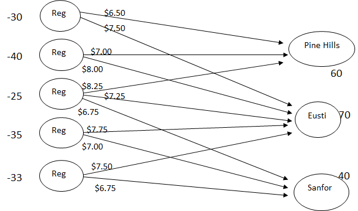

Ogni freccia nel grafico rappresenta una variabile decisionale, ad ogni freccia è associato il rispettivo costo.

Rappresentiamo con i le rgioni, i = {1,2,3,4,5} mentre con j rispettivamente Pine Hills, Eusti, Sanfor, j = {1,2,3}  
La funzione obiettivo quindi diventa:

- min 6.5x<sub>1,1</sub> + 7.5x<sub>1,2</sub> + 1000x<sub>1,3</sub> + 7x<sub>2,1</sub> + 8x<sub>2,2</sub> + 1000x<sub>2,3</sub> + 8.25x<sub>3,1</sub>+7.25x<sub>3,2</sub> + 6.75x<sub>3,3</sub> + 1000x<sub>4,1</sub>+7.75x<sub>4,2</sub> + 7x<sub>4,3</sub> + 1000x<sub>5,1</sub> + 7.5x<sub>5,2</sub> + 6.75x<sub>5,3</sub>
  Limiti per i tre uffici satellitari:
  $$\sum_{i = 1}^{5} x_{i, 1} \leq 60000 \\
  \sum_{i = 1}^{5} x_{i, 2} \leq 70000 \\
  \sum_{i = 1}^{5} x_{1,3} \leq 40000 \\$$
  Limite di clienti:

$$\sum_{j = 1}^{3} x_{1,j} = 30000 \\
\sum_{j = 1}^{3} x_{2, j} = 40000 \\
\sum_{j = 1}^3 x_{3, j} = 25000 \\
\sum_{j = 1}^{3} x_{4, j} = 35000 \\
\sum_{j = 1}^{3} x_{5, j} = 33000 \\$$
Dobbiamo inoltre impostare l’interezza e la non negatività delle variabili.

2) Implement your model and solve it.

```r
model = make.lp(0,11)
lp.control(model, sense="min")
```

[output not shown]

[output cut: 12 more lines]

[output not shown]

```r
set.objfn(model, c(6.5, 7.5, 7, 8, 8.25, 7.25, 6.75, 7.75, 7, 7.5, 6.75))
add.constraint(model, c(1, 1, 1), "<=", 60000 , c(1, 3, 5))
add.constraint(model, c(1, 1, 1, 1, 1), "<=", 70000 ,c(2, 4, 6, 8, 10))
add.constraint(model, c(1, 1, 1), "<=", 40000 ,c(7, 9, 11))

add.constraint(model, c(1, 1), ">=", 30000 , c(1, 2))
add.constraint(model, c(1, 1), ">=", 40000 ,c(3, 4))
add.constraint(model, c(1, 1, 1), ">=", 25000 ,c(5, 6, 7))
add.constraint(model, c(1, 1), ">=", 35000 , c(8, 9))
add.constraint(model, c(1, 1), ">=",33000 ,c(10, 11))

set.bounds(model,lower=c(rep(0, 11)))
set.type(model, c(seq(1, 11)), type = "integer")
```

3. What is the optimal solution?

```r
solve(model)
```

```
## [1] 0
```

```r
get.objective(model)
```

```
## [1] 1155000
```

```r
get.variables((model))
```

```
##  [1] 20000 10000 40000     0     0 25000     0     0 35000 28000  5000
```

Il costo minimizzato della soluzione ottimale è 1155000$, dove vengono assegnati 20000 clienti alla prima regione nell’ufficio di Pine Hills, 10000 clienti della prima regione all’ufficio Eustis ecc…